# 第1回 ガイダンス：Pythonの基本動作と、分析プロセスの全体像

## 気温帯ごとに、平均を出す

6節 ② 気温帯で分ける●○○○○○○

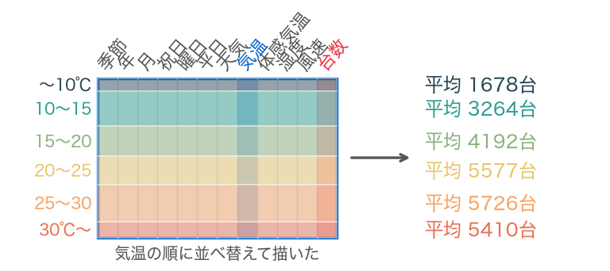

- 同じ気温帯の日をまとめ、帯ごとに平均する。4節の絞り込みを、全部の帯で一度に

## 変えてみる：気温帯ごとに平均

6節 ② 気温帯で分ける●●○○○○○

```python
bins = [0, 10, 15, 20, 25, 30, 40]     # おおむね5度刻み
df['気温帯'] = pd.cut(df['気温'] * 41, bins=bins)
g = df.groupby('気温帯', observed=True)['台数']
g.agg(['mean', 'count']).round(0)
```

- `pd.cut`で、気温を気温帯に分ける。おおむね5℃刻み（両端は10℃幅）
- `groupby('気温帯')`で同じ帯の日をまとめ、`agg`で平均と日数を出す

## 暖かい帯ほど、平均が高い

6節 ② 気温帯で分ける●●●○○○○

| 気温帯 | mean | count |
| --- | --- | --- |
| (0, 10] | 1678.0 | 60 |
| (10, 15] | 3264.0 | 161 |
| (15, 20] | 4192.0 | 138 |
| (20, 25] | 5577.0 | 130 |
| (25, 30] | 5726.0 | 170 |
| (30, 40] | 5410.0 | 72 |

- 10℃以下の1678台（4節の寒い日と同じ）から、25〜30℃の5726台まで上がる

## 30℃を超えると？

6節 ② 気温帯で分ける●●●●○○○

| 気温帯 | mean | count |
| --- | --- | --- |
| (0, 10] | 1678.0 | 60 |
| (10, 15] | 3264.0 | 161 |
| (15, 20] | 4192.0 | 138 |
| (20, 25] | 5577.0 | 130 |
| (25, 30] | 5726.0 | 170 |
| (30, 40] | 5410.0 | 72 |

- 5410台に下がる。散布図で見た「暑すぎると頭打ち」が、ここにも出ている

## 帯の平均を、その帯の日の答えに

6節 ② 気温帯で分ける●●●●●○○

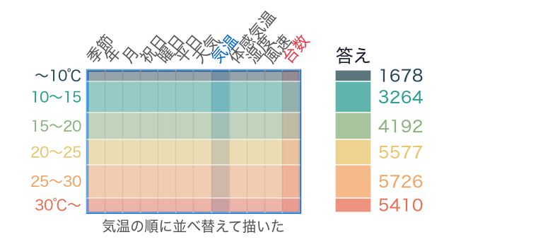

- 27℃の日には、25〜30℃の平均5726台を答えとして付ける
- 式では $\hat{y}_i = \bar{y}_{g(i)}$。$g(i)$は、$i$日目が入る気温帯

## 変えてみる：平均を答えにする

6節 ② 気温帯で分ける●●●●●●○

```python
pred = df.groupby('気温帯', observed=True)['台数'].transform('mean')
print('外れ幅の平均:', round((df['台数'] - pred).abs().mean()), '台')
```

- `transform('mean')`は、グループの平均を、そのグループの1日1日に配り直す
- 外れ幅の計算は、お手本と同じ

## 1582台から1211台へ

6節 ② 気温帯で分ける●●●●●●●

```
外れ幅の平均: 1211 台
```

- 気温帯で分けるだけで、外れ幅は1582台から1211台に縮んだ

## 変えてみる：年と天気でも分ける

6節 ③ 年と天気でも●○○

```python
for keys in [['気温帯', '年'], ['気温帯', '年', '天気']]:
    pred = df.groupby(keys, observed=True)['台数'].transform('mean')
    print(keys, '→', round((df['台数'] - pred).abs().mean()), '台')
```

- `groupby`に列のリストを渡すと、条件の組み合わせでグループができる
- 4節で見た「年」と、TODO③の「天気」を足す

## 年も分けると、ほぼ半分

6節 ③ 年と天気でも●●○

```
['気温帯', '年'] → 762 台
['気温帯', '年', '天気'] → 665 台
```

- 気温帯×年で762台。基準の1582台から、ほぼ半分になった

## 天気も足すと、665台

6節 ③ 年と天気でも●●●

```
['気温帯', '年'] → 762 台
['気温帯', '年', '天気'] → 665 台
```

- 縮みはするが、縮み方は小さくなってきた

## TODO④：外れ幅を縮めよう

6節 ④ 確かめる●○○

```python
# TODO: 分ける列のリストを keys に入れ、外れ幅の平均を計算する
# ヒント1: すぐ上のセルの for 文の中身を、1回ぶん書けばよい
# ヒント2: keys = ['気温帯', '年', '季節'] のように並べる
...
```

- 使える列：`気温帯`・`季節`・`年`・`月`・`祝日`・`曜日`・`平日`・`天気`

## やってみよう：6節とTODO④

6節 ④ 確かめる●●○

- 6節のセルを実行し、ここまでと同じ外れ幅が出るか確かめる
- TODO④：分ける列を選び、外れ幅をどこまで縮められるか試す

動画の人は、ここで一時停止。

## 答え合わせ：TODO④の例

6節 ④ 確かめる●●●

```
['気温帯', '年', '月'] → 614 台
```

- 気温帯×年×月で614台。組み合わせしだいで、まだ縮む

## 細かく分けるほど、当たる？

6節 ⑤ 分けすぎると●○○○○

```python
keys = ['月', '年', '天気', '曜日']
g = df.groupby(keys, observed=True)['台数']
pred = g.transform('mean')
print('外れ幅の平均:', round((df['台数'] - pred).abs().mean()), '台')
print('グループの数:', g.ngroups)
print('1日しかないグループ:', int((g.size() == 1).sum()))
```

- 月×年×天気×曜日で分けてみる
- `g.ngroups`はグループの数、`g.size()`は各グループの日数

## 外れ幅は、408台

6節 ⑤ 分けすぎると●●○○○

```
外れ幅の平均: 408 台
グループの数: 326
1日しかないグループ: 101
```

- ずいぶん縮んだ。でも、グループの中身を見ると？

## 101グループは、1日しかない

6節 ⑤ 分けすぎると●●●○○

```
外れ幅の平均: 408 台
グループの数: 326
1日しかないグループ: 101
```

- 326グループのうち101グループは、1日だけ

## 自分自身を答えにしていた

6節 ⑤ 分けすぎると●●●●○

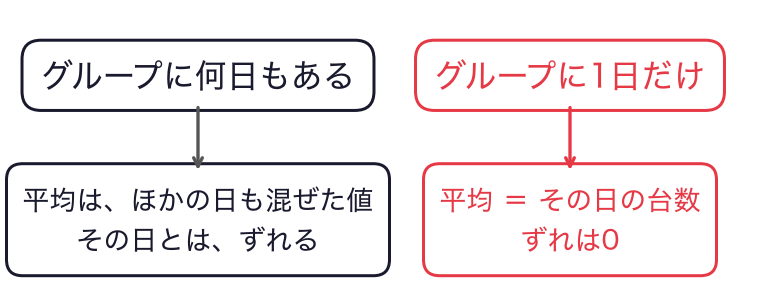

- 1日だけのグループでは、自分の台数を答えにしている。外れが0になって当然

## まだ来ていない明日では？

6節 ⑤ 分けすぎると●●●●●

- 今日の採点は、すべて平均を作るのに使った日で行っている
- まだ来ていない明日で、本当に当たるのか？

# 7. 運営者への答え

## 分けすぎない。気温帯×年×天気で

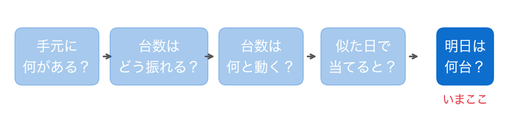

- 明日が25〜30℃・2年目・晴れなら、同じ条件の日は何台だったか

## 同じ条件の日を、表から集める

7節 ① 同じ条件の日●○○○○

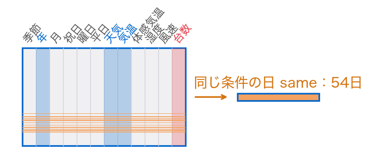

- 4節と同じく、条件を3つ重ねて絞る。その平均が答え

## 気温帯の1つを、どう書く？

7節 ① 同じ条件の日●●○○○

```
0    (10, 15]
1    (10, 15]
2     (0, 10]
```

- `pd.cut`が作った気温帯は、`(25, 30]`のような区間
- `pd.Interval(25, 30)`と書くと、この「25℃より上、30℃以下」を表せる

## お手本：明日の条件で絞る

7節 ① 同じ条件の日●●●○○

```python
same = df[(df['気温帯'] == pd.Interval(25, 30))
          & (df['年'] == 1) & (df['天気'] == 1)]
print('同じ条件の日:', len(same), '日')
print('平均:', round(same['台数'].mean()), '台')
print('その中での外れ幅の平均:',
      round((same['台数'] - same['台数'].mean()).abs().mean()), '台')
```

- 最後の行は、同じ条件の日の中での外れ幅の平均（6節と同じ測り方）

## 54日、平均7198台

7節 ① 同じ条件の日●●●●○

```
同じ条件の日: 54 日
平均: 7198 台
その中での外れ幅の平均: 493 台
```

- 54日あり、平均7198台。その中でも平均493台は外れる

## 答え：およそ7200台

7節 ① 同じ条件の日●●●●●

```
同じ条件の日: 54 日
平均: 7198 台
その中での外れ幅の平均: 493 台
```

およそ7200台。平均して500台くらいずれる。

## やってみよう：7節

7節 ② 確かめる●

- 7節のお手本のセルを実行し、同じ答えが出るか確かめる

動画の人は、ここで一時停止。

## まだ言えないこと①：本当の実力

7節 ③ まだ言えないこと●○○

- 作るのに使った日で採点している
- まだ来ていない日で試すと、どうなるか？

## まだ言えないこと②：ガタガタの段

7節 ③ まだ言えないこと●●○

- 気温帯の境目で、答えが跳ぶ。24.9℃と25.1℃で答えが変わる
- 気温を入れると台数が出てくる、1本の式が欲しい

## まだ言えないこと③：因果

7節 ③ まだ言えないこと●●●

- 「暖かくすれば、客が増える」とは言えない
- 季節が、気温と台数の両方を動かしているかもしれない

# まとめ

## 今日の道筋を、振り返る

⑤ 振り返る●○○

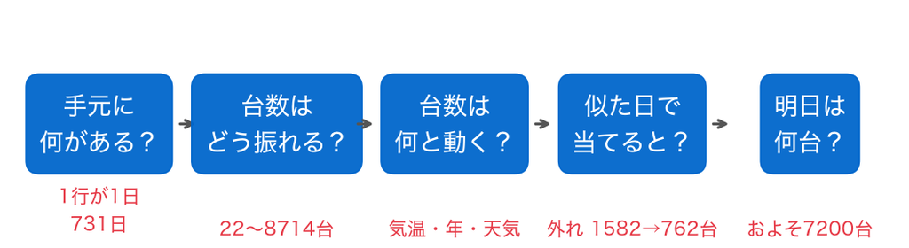

- 5つの小さな問いに答えて、明日の台数にたどり着いた

## 今日の歩み

⑤ 振り返る●●○

データを理解して目標を定め、似た日の平均で当て、答えと限界を目標に照らした

## 今日の要点

⑤ 振り返る●●●

- 問い（明日何台？）は、答えられる形（似た日は何台だった？）に言い換える
- 当てる前に、基準（毎日平均で1582台外れる）を置く
- 手がかりで分けると、外れ幅が縮む。気温帯×年で762台、ほぼ半分
- 細かく分けすぎると、自分自身を答えにして採点してしまう
- pandasの4つ：読む（`read_csv`）・選ぶ（`df['台数']`）・絞る（`df[条件]`）・まとめる（`groupby`）

## 課題の出し方

⑥ このあと●○○○

- ノートの最後の「課題（提出）」に取り組む
- 応用②の答えと応用③の文章を、LACSに入力して提出（＝出席。期限なし）
- AIを使ってもよい。何を聞いて、どう直したかを1行書く

## 次回予告：この段を、1本の式に

⑥ このあと●●○○

- 気温を入れると台数が出てくる、直線の式を立てる
- 「良い直線」を選ぶ物差しを考える

## 次回の問い

⑥ このあと●●●○

その式は、まだ来ていない日にも当たるのか？

## このあと：課題へ

⑥ このあと●●●●

ノートの「課題（提出）」へ。時間別のデータで、1日の中の利用の波を見ます。